# DADA2 + PacBio: HMP Mock Community

Benjamin J Callahan

7/19/2018

## Data

The mock community being sequenced is the BEI Resources Microbial Mock Community B (Staggered, Low Concentration) community: https://www.beiresources.org/Catalog/otherProducts/HM-783D.aspx. This mock community (also known as the HMP mock community) contains the following bacterial in the following table, adapted from Table 1 in the BEI document, with alternative strain names and 16S copy numbers added based on the NCBI entry.

| Organism | NCBI Reference Sequence |
| --- | --- |
| Acinetobacter baumannii, strain 5377 | NC_009085 |
| Actinomyces odontolyticus, strain 1A.21 | NZ_AAYI02000000 |
| Bacillus cereus, strain NRS 248 | NC_003909 |
| Bacteroides vulgatus, strain ATCC® 8482 | NC_009614 |
| Clostridium beijerinckii, strain NCIMB 8052 | NC_009617 |
| Deinococcus radiodurans, strain R1 (smooth) | NC_001263, NC_001264 |
| Enterococcus faecalis, strain OG1RF | NC_017316 |
| Escherichia coli, strain K12, substrain MG1655 | NC_000913 |
| Helicobacter pylori, strain 26695 | NC_000915 |
| Lactobacillus gasseri, strain 63 AM | NC_008530 |
| Listeria monocytogenes, strain EGDe | NC_003210 |
| Neisseria meningitidis, strain MC58 | NC_003112 |
| Propionibacterium acnes, strain KPA171202 | NC_006085 |
| Pseudomonas aeruginosa, strain PAO1-LAC | NC_002516 |
| Rhodobacter sphaeroides, strain ATH 2.4.1 | NC_007493, NC_007494 |
| Staphylococcus aureus, strain TCH1516 | NC_010079 |
| Staphylococcus epidermidis, FDA strain PCI 1200 | NC_004461 |
| Streptococcus agalactiae, strain 2603 V/R | NC_004116 |
| Streptococcus mutans, strain UA159 | NC_004350 |
| Streptococcus pneumoniae, strain TIGR4 | NC_003028 |

> Acknowledgment for publications should read “The following reagent was obtained through BEI Resources, NIAID, NIH as part of the Human Microbiome Project: Genomic DNA from Microbial Mock Community B (Staggered, Low Concentration), v5.2L, for 16S rRNA Gene Sequencing, HM-783D.”

This sequencing data was generated by PacBio using their in-house 16S amplification and sequencing protocol: https://www.pacb.com/wp-content/uploads/Unsupported-Full-Length-16S-Amplification-SMRTbell-LibraryPreparation-and-Sequencing.pdf *(everying is the same as the processing for the Zymo mock community)*

The sequencing was performed on a Sequel, with the S/P1-C1.2 sequencing chemistry. Standard PacBio bioinformatics were performed, and consensus sequences were extracting using CCS 3.1.1 with default parameters, `minPasses=3` and `minPredictedAccuracy=0.999`:

`ccs --pbi --force --logLevel=DEBUG --numThreads=16 --minSnr=3.75 --minReadScore=0.65 --maxLength=7000 --minLength=10 --minPasses=3 --minZScore=-5 --maxDropFraction=0.34 --minPredictedAccuracy=0.999 subreads.bam ccs.bam`

## Setup

Load libraries, setup paths, prepare environment:

```r
library(dada2);packageVersion("dada2")
```

```
## [1] '1.12.1'
```

```r
library(Biostrings); packageVersion("Biostrings")
```

```
## [1] '2.46.0'
```

```r
library(ggplot2); packageVersion("ggplot2")
```

```
## [1] '3.1.0'
```

```r
library(reshape2); packageVersion("reshape2")
```

```
## [1] '1.4.3'
```

```r
path <- "~/Desktop/LRAS/Data/BEI" # CHANGE ME to location of the fastq file
path.out <- "Figures/"
path.rds <- "RDS/"
fn <- file.path(path, "SO_BEI-stagLo-16S_CCS-99.9.fq.gz")
F27 <- "AGRGTTYGATYMTGGCTCAG"
R1492 <- "RGYTACCTTGTTACGACTT"
rc <- dada2:::rc
theme_set(theme_bw())
```

## Remove Primers and Filter

Remove primers and orient reads:

```r
nop <- file.path(path, "noprimers", basename(fn))
prim <- removePrimers(fn, nop, primer.fwd=F27, primer.rev=dada2:::rc(R1492), orient=TRUE, verbose=TRUE)
```

```
## Multiple matches to the primer(s) in some sequences. Using the longest possible match.
```

```
## Multiple matches to the primer(s) in some reverse-complement sequences. Using the longest possible match.
```

```
## 39947 sequences out of 78328 are being reverse-complemented.
```

```
## Overwriting file:/Users/bcallah/Desktop/LRAS/Data/BEI/noprimers/SO_BEI-stagLo-16S_CCS-99.9.fq.gz
```

```
## Read in 78328, output 73939 (94.4%) filtered sequences.
```

Very little loss there even though primer indels aren’t allowed currently.

Inspect length distribution.

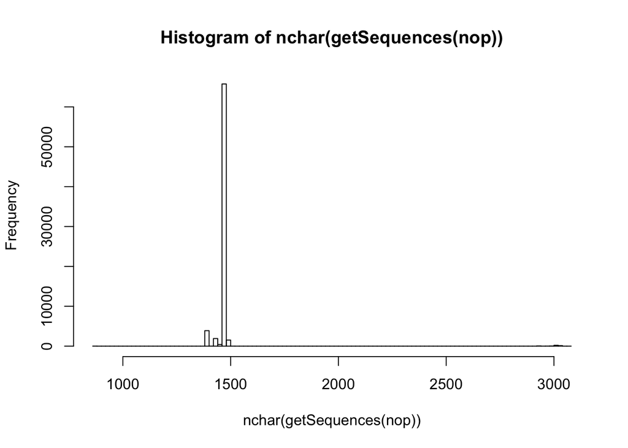

```r
hist(nchar(getSequences(nop)), 100)
```

Very strong peak ~1450. Perhaps some secondary peake nearby, should carry through further sequencing.

Filter:

```r
filt <- file.path(path, "noprimers", "filtered", basename(fn))
track <- filterAndTrim(nop, filt, minQ=3, minLen=1000, maxLen=1600, maxN=0, rm.phix=FALSE, maxEE=2, verbose=TRUE)
```

```
## Overwriting file:/Users/bcallah/Desktop/LRAS/Data/BEI/noprimers/filtered/SO_BEI-stagLo-16S_CCS-99.9.fq.gz
```

```
## Read in 73939, output 69963 (94.6%) filtered sequences.
```

## Run DADA2

Dereplicate:

```r
drp <- derepFastq(filt, verbose=TRUE)
```

```
## Dereplicating sequence entries in Fastq file: ~/Desktop/LRAS/Data/BEI/noprimers/filtered/SO_BEI-stagLo-16S_CCS-99.9.fq.gz
```

```
## Encountered 19873 unique sequences from 69963 total sequences read.
```

Learn errors:

```r
err <- learnErrors(drp, BAND_SIZE=32, multithread=TRUE, errorEstimationFunction=dada2:::PacBioErrfun) # seconds
```

```
## 102693885 total bases in 69963 reads from 1 samples will be used for learning the error rates.
```

Looks good.

Inspect errors:

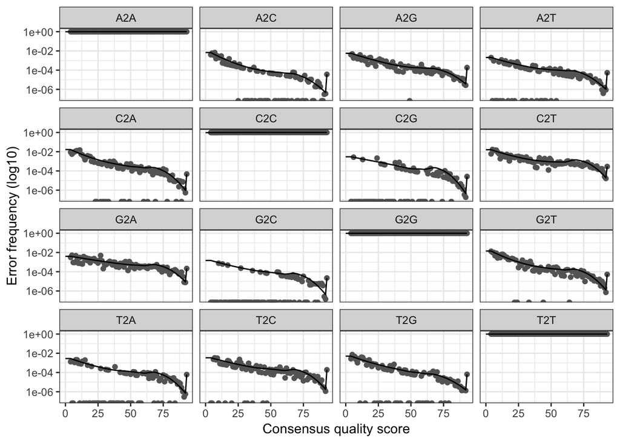

```r
plotErrors(err)
```

Denoise:

```r
dd <- dada(drp, err=err, BAND_SIZE=32, multithread=TRUE)
```

```
## Sample 1 - 69963 reads in 19873 unique sequences.
```

```r
dd
```

```
## dada-class: object describing DADA2 denoising results
## 51 sequence variants were inferred from 19873 input unique sequences.
## Key parameters: OMEGA_A = 1e-40, OMEGA_C = 1e-40, BAND_SIZE = 32
```

Read tracking:

```r
cbind(ccs=prim[,1], primers=prim[,2], filtered=track[,2], denoised=sum(dd$denoised))
```

```
##        ccs primers filtered denoised
## [1,] 78328   73939    69963    69911
```

Inspect clustering data.frame

```r
sq <- dd$sequence
dd$clustering[,-1]
```

```
##    abundance    n0   n1 nunq          pval birth_type    birth_pval
## 1      14640 12410 2048 3406  0.000000e+00          I            NA
## 2       8286  7074 1097 2185  0.000000e+00          A  0.000000e+00
## 3       6713  5623 1009 1778  0.000000e+00          A  0.000000e+00
## 4       4215  3582  577 1178  0.000000e+00          A  0.000000e+00
## 5       3702  3139  518 1014  0.000000e+00          A  0.000000e+00
## 6       3687  3178  458 1051  0.000000e+00          A  0.000000e+00
## 7       3639  3144  460 1046  0.000000e+00          A  0.000000e+00
## 8       3371  2921  403  949  0.000000e+00          A  0.000000e+00
## 9       3276  2774  464  996  0.000000e+00          A  0.000000e+00
## 10      2917  2502  381  848  0.000000e+00          A  0.000000e+00
## 11      1971  1668  269  627  0.000000e+00          A  0.000000e+00
## 12      1810  1520  262  599  0.000000e+00          A  0.000000e+00
## 13      1752  1475  246  581  0.000000e+00          A  0.000000e+00
## 14      1761  1500  231  604  0.000000e+00          A  0.000000e+00
```

[output cut: 89 more lines]

Big jump from pval 10-126 to below the threshold at `OMEGA_A=10^40`.

Assign taxonomy:

```r
tax <- assignTaxonomy(dd, "~/tax/silva_nr_v128_train_set.fa.gz", multithread=TRUE)
tax[,"Genus"] <- gsub("Escherichia/Shigella", "Escherichia", tax[,"Genus"]) # Reformat to be compatible with other data sources
tax[,"Genus"] <- gsub("Clostridium_sensu_stricto_1", "Clostridium", tax[,"Genus"]) # Reformat to be compatible with other data sources
unname(tax)
```

```
##       [,1]       [,2]             [,3]
##  [1,] "Bacteria" "Firmicutes"     "Bacilli"
##  [2,] "Bacteria" "Firmicutes"     "Bacilli"
##  [3,] "Bacteria" "Firmicutes"     "Bacilli"
##  [4,] "Bacteria" "Firmicutes"     "Bacilli"
##  [5,] "Bacteria" "Proteobacteria" "Alphaproteobacteria"
##  [6,] "Bacteria" "Firmicutes"     "Bacilli"
##  [7,] "Bacteria" "Firmicutes"     "Bacilli"
##  [8,] "Bacteria" "Firmicutes"     "Bacilli"
##  [9,] "Bacteria" "Proteobacteria" "Gammaproteobacteria"
## [10,] "Bacteria" "Firmicutes"     "Bacilli"
## [11,] "Bacteria" "Proteobacteria" "Gammaproteobacteria"
## [12,] "Bacteria" "Proteobacteria" "Gammaproteobacteria"
## [13,] "Bacteria" "Proteobacteria" "Gammaproteobacteria"
## [14,] "Bacteria" "Proteobacteria" "Gammaproteobacteria"
```

[output cut: 89 more lines]

Plot abundances:

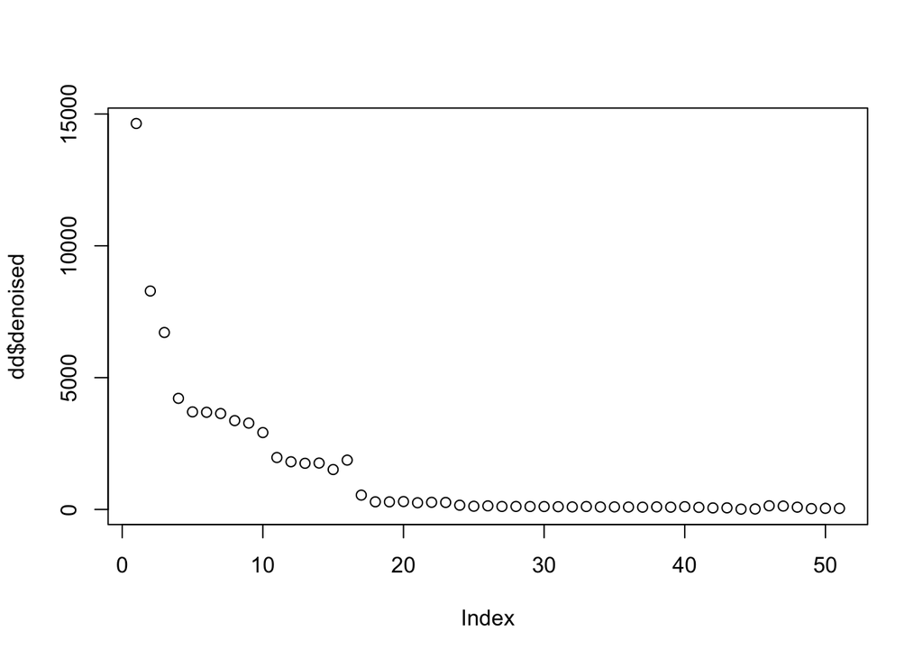

```r
plot(dd$denoised)
```

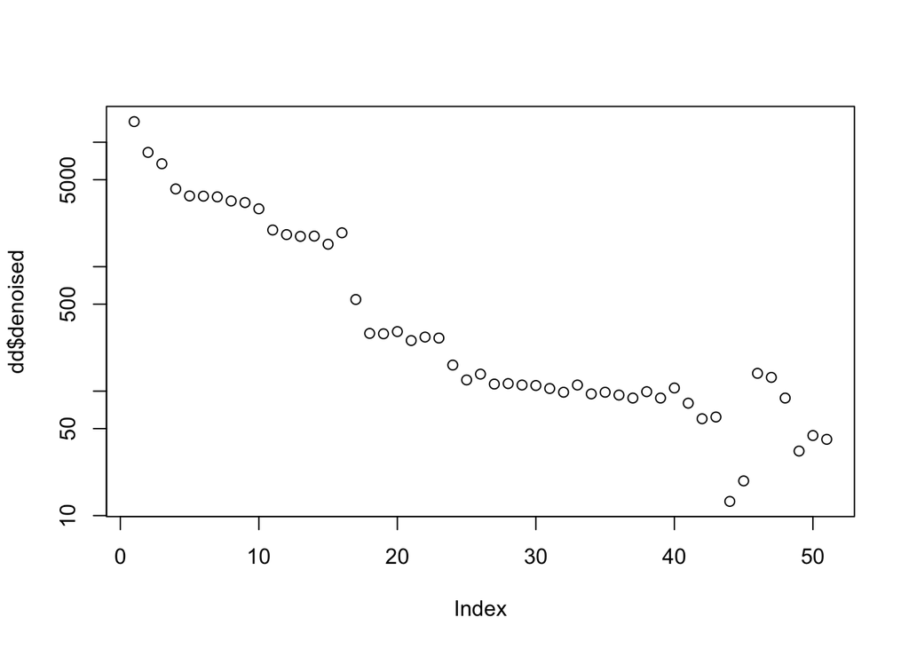

```r
plot(dd$denoised, log="y")
```

Broad range of abundances over 3 orders of magnitude (10-10000).

Check chiemras:

```r
bim <- isBimeraDenovo(dd, minFoldParentOverAbundance=3.5, multithread=TRUE)
# Higher MFPOA to avoid flagging intra-genomic variants
table(bim)
```

```
## bim
## FALSE
##    51
```

No chimeras!

```r
table(tax[,"Genus"])
```

```
##
##     Acinetobacter          Bacillus       Bacteroides       Clostridium
##                 1                 3                 1                15
##      Enterococcus       Escherichia      Helicobacter     Lactobacillus
##                 1                 6                 1                 1
##          Listeria         Neisseria Propionibacterium       Pseudomonas
##                 4                 1                 1                 2
##       Rhodobacter    Staphylococcus     Streptococcus
##                 1                10                 3
```

Save processed objects for future analysis.

```r
saveRDS(dd, file.path(path.rds, "HMP_dd.rds"))
saveRDS(tax, file.path(path.rds, "HMP_tax_Silva128.rds"))
```

Reload processed data objects (can run code below from here in absence of input sequence data):

```r
dd <- readRDS(file.path(path.rds, "HMP_dd.rds"))
tax <- readRDS(file.path(path.rds, "HMP_tax_Silva128.rds"))
```

## Reference check againt nt

BLAST these 51 sequences against nt (https://blast.ncbi.nlm.nih.gov/Blast.cgi):

```r
## dada2:::pfasta(dd, id=tax[,6])
uniquesToFasta(dd, file.path(path.rds, "LRAS_HMP_ASVs.fa"), ids=paste0(tax[,"Genus"], ";size=", dd$denoised, ";"))
is.ec <- tax[,"Genus"] %in% "Escherichia"
uniquesToFasta(dd$clustering[is.ec,], file.path(path.rds, "HMP_Ecoli.fa"), ids=paste0("Ecoli", seq(sum(is.ec)), "_HMP"))
## BLAST against nt excluding uncultured/environmental sequences (checkbox)
```

Results of BLAST search on July 19, 2018 are recorded.

1. Exact match to Strep. mutans strains: NG8, UA159-FR, UA159, NN2025 DNA, ChDC YM216, ChDC YM97, ChDC YM64, ChDC YM220
2. Exact match to Staph. epidermis ATCC 12228
3. Exact match to Strep. mutans strains: UA159, ChDC YM89
4. Exact match to many (~40) Staph. epidermis strains.
5. Exact match to many (~20) Rhodobacter sphaeroides strains.
6. Exact match to Staph. epidermis strains: FDAARGOS, RP62A
7. *Two mismatches (consecutive) to Staph. epidermidis strains: FDAARGOS_161, 1457, PM221* Query: 1235/6 AA, Refs: GG
8. Exact match to Staph. epidermis strains: RP62A, ATCC 12228
9. Exact match to many (>100) E. coli strains.
10. Exact match to many (~50) Strep. agalactiae strains.
11. Exact match to many (>100) E. coli strains.
12. Exact match to many (~90) E. coli strains.
13. Exact match to many (>100) E. coli strains.
14. Exact match to many (~80) E. coli strains.
15. Exact match to many (~50) E. coli strains.
16. Exact match to Bacillus cereus strains: M3, LWYT0010, LWYT0301, FRI-35, PPB, ATCC 10987
17. Exact match to many (>100) Staph. aureus strains.
18. Exact match to many (99) Staph. aureus strains.
19. Exact match to Helicobacter pylori strains: dRdM2addM2, 26695-dR, 26695-dRdM1dM2, 26695-dRdM2, dRdM1
20. Exact match to many (~15) Staph. aureus strains.
21. Exact match to Lactobacillus gasseri strains: ATCC 33323, Floraactive 18911-2, ATCC 33323, ATCC 33323, ATCC 33323
22. Exact match to many (~70) Staph. aureus strains.
23. Exact match to many (~60) Staph. aureus strains.
24. Exact match to Neisseria meningitidis strains: FDAARGOS_210, LNP21362, H44/76, MC58
25. Exact match to Clostridium beijerinckii strains: DSM 6423, ATCC 35702, N7, NCIMB 8052
26. Exact match to many (>100) Pseudomonas aeruginosa strains.
27. Exact match to Clostridium beijerinckii strains: BAS/B3/I/124, MF28, NCIMB 14988, ATCC 35702, NCIMB 8052
28. Exact match to many (~95) Acinetobacter baumannii strains.
29. Exact match to Clostridium beijerinckii strains: ATCC 35702, NCIMB 8052
30. Exact match to Clostridium beijerinckii strains: ATCC 35702, NCIMB 8052
31. Exact match to Clostridium beijerinckii strains: ATCC 35702, NCIMB 8052
32. Exact match to Clostridium beijerinckii strains: ATCC 35702, NCIMB 8052
33. Exact match to Clostridium sp. strain: MF28 (unnamed, but 1-off from C. beijerinckii, 2-ff from 35702/8052)
34. *One mismatch to Clostridium beijerinckii strains: ATCC 35702, NCIMB 8052, JCM 8023*: Query 955T, Refs C
35. Exact match to Clostridium beijerinckii strains: ATCC 35702, NCIMB 8052
36. Exact match to Clostridium beijerinckii strains: ATCC 35702, NCIMB 8052
37. *One mismatch to Clostridium beijerinckii strains: ATCC 35702, NCIMB 8052, NCIMB 14988*: Query 231C, Ref T OR Query 1209T, Refs C
38. Exact match to Clostridium beijerinckii strains: ATCC 35702, NCIMB 8052
39. Exact match to Clostridium beijerinckii strains: ATCC 35702, NCIMB 8052, NRRL B-598
40. Exact match to Clostridium beijerinckii strains: ATCC 35702, NCIMB 8052
41. Exact match to many (>100) Listeria monocytogenes strains.
42. Exact match to many (~30) Listeria monocytogenes strains.
43. Exact match to many (~15) Propionibacterium/Cutibacterium acnes strains. (P.acnes -> C.acnes name change)
44. Exact match to many (~50) Enterococcus faecalis strains.
45. Exact match to Bacteroides vulgatus ATCC 8482
46. Exact match to Bacillus cereus ATCC 10987
47. Exact match to Bacillus cereus ATCC 10987 (one mismatch in web BLAST due to not handling ambiguous nt code S in reference)
48. Exact match to Clostridium beijerinckii strains: ATCC 35702, NCIMB 8052, JCM 8023
49. Exact match to many (~70) Listeria monocytogenes strains.
50. Exact match to Pseudomonas aeruginosa strains: ATCC 15692, PAO1OR, PAO1H2O, PAO1-VE13, PAO1-VE2, PAO581, c7447m
51. Exact match to many (~30) Listeria monocytogenes strains.

Store these results in R format:

```r
refhit.nt <- ifelse(seq_along(sq) %in% c(7, 34, 37), FALSE, TRUE)
which(!refhit.nt)
```

```
## [1]  7 34 37
```

48/51 of these are exact matches to sequenced and cultured isolates, over their entire ~1.5Kb length!

*Actinomyces odontolyticus*, *Deinococcus radiodurans* and *Streptococcus pneumoniae* were expected members of this mock community that were not detected in the data.

Let’s deconvolute a couple strains by assigning species based on BLAST results to genera with multiple species (*Staphylococcus* and *Streptococcus*):

```r
tax[c(1,3),"Genus"] <- "Streptococcus mutans"
tax[10,"Genus"] <- "Streptococcus agalactiae"
tax[c(2,4,6,7,8),"Genus"] <- "Staphylococcus epidermis"
tax[c(17,18,20,22,23),"Genus"] <- "Staphylococcus aureus"
```

## Reference check against 16S references

BEI does not provide reference sequences for these strains. However, Robert Edgar has generated a set of references sequences as best he can based on publicy deposited genomes, and we will use that here:

```r
fn16S <- file.path("Docs/BEI_Reference_Edgar.fa")
refs <- getSequences(fn16S)
unique(sapply(strsplit(names(refs), "\\s"), function(x) paste(x[2], x[3])))
```

```
##  [1] "Streptococcus agalactiae"   "Lactobacillus gasseri"
##  [3] "Bacillus cereus"            "Acinetobacter baumannii"
##  [5] "Porphyromonas gingivalis"   "Actinomyces odontolyticus"
##  [7] "Streptococcus pneumoniae"   "Neisseria meningitidis"
##  [9] "Streptococcus mutans"       "Enterococcus faecalis"
## [11] "Rhodobacter sphaeroides"    "Propionibacterium acnes"
## [13] "Pseudomonas aeruginosa"     "Deinococcus radiodurans"
## [15] "Bacteroides vulgatus"       "Escherichia coli"
## [17] "Listeria monocytogenes"     "Staphylococcus aureus"
## [19] "Clostridium beijerinckii"   "Methanobrevibacter smithii"
## [21] "Staphylococcus epidermidis" "Helicobacter pylori"
```

Twenty-two species, whereas only twenty expected in this HMP mock. The extra taxa are *Methanobrevibacter smithii* and *Porphyromonas gingivalis*, otherwise everything matches expectations.

Name the reference sequences something useful and count the number of unique (I think) variants in each:

```r
ref.16S <- getSequences(fn16S)
genus.spc <- sapply(strsplit(names(ref.16S), "\\s"), function(x) paste(x[2], x[3], sep="_"))
variant <- sapply(seq_along(genus.spc), function(i) sum(genus.spc[1:i] == genus.spc[[i]]))
names(ref.16S) <- paste(genus.spc, variant, sep="_")
nunq.ref <- table(genus.spc)
nunq.ref
```

```
## genus.spc
##    Acinetobacter_baumannii  Actinomyces_odontolyticus
##                          1                          1
##            Bacillus_cereus       Bacteroides_vulgatus
##                          7                          6
##   Clostridium_beijerinckii    Deinococcus_radiodurans
##                         14                          2
##      Enterococcus_faecalis           Escherichia_coli
##                          2                          6
##        Helicobacter_pylori      Lactobacillus_gasseri
##                          2                          1
##     Listeria_monocytogenes Methanobrevibacter_smithii
##                          4                          2
##     Neisseria_meningitidis   Porphyromonas_gingivalis
##                          1                          1
##    Propionibacterium_acnes     Pseudomonas_aeruginosa
##                          2                          2
##    Rhodobacter_sphaeroides      Staphylococcus_aureus
##                          2                          4
## Staphylococcus_epidermidis   Streptococcus_agalactiae
##                          5                          1
##       Streptococcus_mutans   Streptococcus_pneumoniae
##                          2                          1
```

```r
table(tax[,"Genus"])
```

```
##
##            Acinetobacter                 Bacillus              Bacteroides
##                        1                        3                        1
##              Clostridium             Enterococcus              Escherichia
##                       15                        1                        6
##             Helicobacter            Lactobacillus                 Listeria
##                        1                        1                        4
##                Neisseria        Propionibacterium              Pseudomonas
##                        1                        1                        2
##              Rhodobacter    Staphylococcus aureus Staphylococcus epidermis
##                        1                        5                        5
## Streptococcus agalactiae     Streptococcus mutans
##                        1                        2
```

Now compare to DADA2 inferred sequences to the reference sequences, allowing no mismatches (but with `fixed=FALSE` so as to match ambiguous nucleotides in the references):

```r
sq <- dd$sequence
refmat.16S <- sapply(DNAStringSet(sq), vcountPattern, subject=DNAStringSet(ref.16S), fixed=FALSE)
rownames(refmat.16S) <- names(ref.16S)
colnames(refmat.16S) <- paste0("Seq", seq_along(sq))
```

Inspect:

```r
refhit.16S <- colSums(refmat.16S)>0
which(!refhit.16S)
```

```
##  Seq4  Seq6  Seq7 Seq19 Seq20 Seq33 Seq34 Seq37
##     4     6     7    19    20    33    34    37
```

```r
table(tax[,"Genus"], Reference.Match=refhit.16S)
```

```
##                           Reference.Match
##                            FALSE TRUE
##   Acinetobacter                0    1
##   Bacillus                     0    3
##   Bacteroides                  0    1
##   Clostridium                  3   12
##   Enterococcus                 0    1
##   Escherichia                  0    6
##   Helicobacter                 1    0
##   Lactobacillus                0    1
##   Listeria                     0    4
##   Neisseria                    0    1
##   Propionibacterium            0    1
##   Pseudomonas                  0    2
##   Rhodobacter                  0    1
##   Staphylococcus aureus        1    4
##   Staphylococcus epidermis     3    2
##   Streptococcus agalactiae     0    1
##   Streptococcus mutans         0    2
```

So 43/51 exactly match against this 16S reference based on the described strains. The 8 that don’t hit include 3/5 *S. epidermis* sequence variants, 1/5 *S. aureus* variants, 1/1 *H. pylori* variant, and 3/15 *C. bejerenckii* variants. They overlap with 1/5 *S. epidermis* variants, and 2/15 *C. bejerenckii* variants that also were not matched against nt.

## Intra-genomic Stoichiometry

Now we’ll investigate the “stoichiometry” of the sequence variants from each bacterial strain, i.e. the copy number of each 16S sequence variants relative to the genomic copy number, all inferred from the dada2 processed data and the rRNA gene copy numbers given for each strain in the Zymo reference.

These 16S copy numbers are based on (1) the NCBI reference sequence annotation if present, (2) an estimate from https://rrndb.umms.med.umich.edu/search/, and (3) inspection of the number of 16S rRNA genes in the best BLAST hits of each strain’s ASVs. If copy number was ambiguous, the best BLAST hits were chosen to break the tie, as likely to most closely capture the actual strain being interrogated here.

```r
ncopy <- c("Acinetobacter" = 6,
           "Actinomyces"=2,
           "Bacillus" = 12,
           "Bacteroides" = 7,
           "Clostridium" = 14,
           "Deinococcus" = 3,
           "Enterococcus" = 4,
           "Escherichia" = 7,
           "Helicobacter" = 2,
           "Lactobacillus" = 6,
           "Listeria" = 6,
           "Neisseria" = 4,
           "Propionibacterium" = 3,
           "Pseudomonas" = 4,
           "Rhodobacter" = 4,
           "Staphylococcus aureus" = 6,
           "Staphylococcus epidermis" = 6,
           "Streptococcus agalactiae" = 7,
           "Streptococcus mutans" = 6,
           "Streptococcus pneumoniae" = 4)
```

First calculate the genomic abundances, by summing over all sequence variants for each genus and dividing by the 16S copy number:

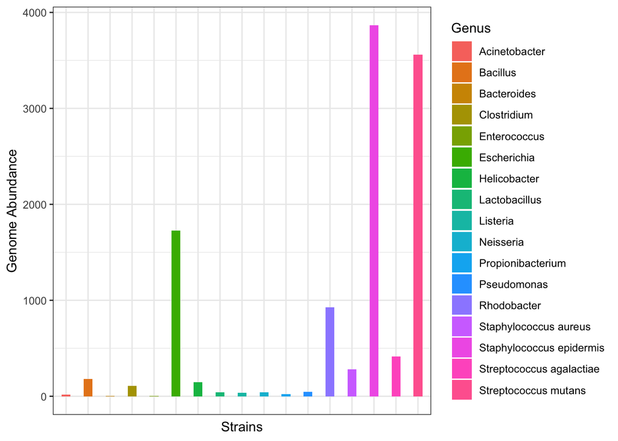

```r
gens <- sort(unique(tax[,"Genus"])) # Just the ones that were detected
abund.ome <- sapply(gens, function(gen) {
  is.gen <- grepl(gen, tax[,"Genus"])
  sum(dd$denoised[is.gen])/ncopy[gen] ###!
###  sum(dd$clustering$n0[is.gen])/ncopy[gen] ###! Alternative w/o error-correction
})
names(abund.ome) <- gens
dfgen <- data.frame(Genus=gens, Abundance=abund.ome, stringsAsFactors = FALSE)
p.abundome <- ggplot(data=dfgen, aes(x=Genus, y=Abundance)) +
  theme(axis.text.x=element_blank(), axis.ticks.x = element_blank()) +
  ylab("Genome Abundance") + xlab("Strains")
p.abundome + geom_col(width=0.4, aes(fill=Genus)) # scale_fill_manual(values=genusPalette) +
```

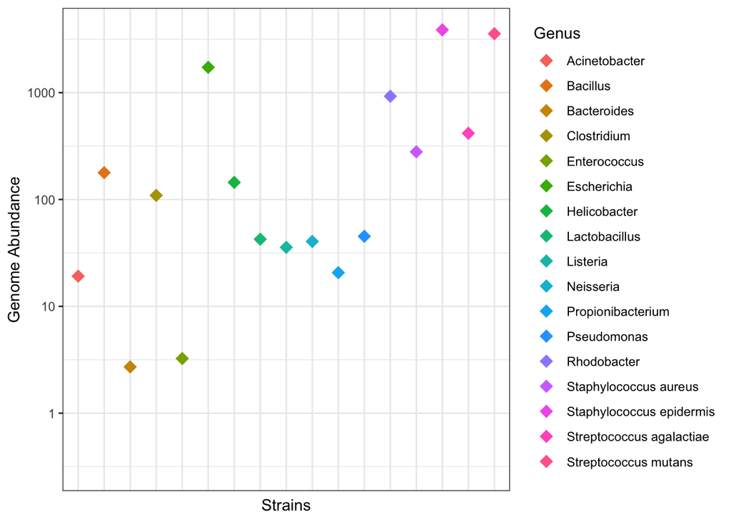

```r
p.abundome.nice <- p.abundome+ geom_point(aes(color=Genus), shape="diamond", size=4) +
  scale_y_log10(limits=c(0.3, NA), breaks=c(1,10,100,1000))
p.abundome.nice
```

```r
ggsave(file.path(path.out, "HMP_GenomeAbundances.pdf"), p.abundome.nice,
       width=6, height=4, units="in", useDingbats=FALSE)
```

Now we make a similar plot for the abundance of each sequence variant:

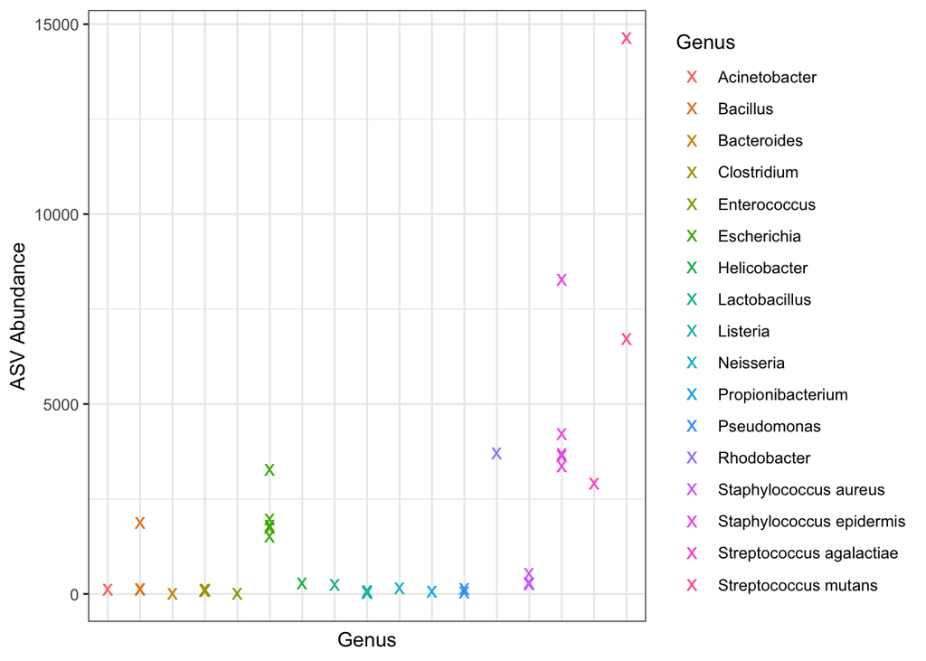

```r
dfasv <- data.frame(Genus=tax[,"Genus"],
                    Abundance=dd$denoised, ###!
                    ### Abundance=dd$clustering$n0, ###! Alternative w/o error-correction
                    stringsAsFactors = FALSE)
rownames(dfasv) <- NULL
p.abundasv <- ggplot(data=dfasv, aes(x=Genus, y=Abundance)) +
  geom_point(aes(color=Genus), shape="x", size=4) +
  ylim(c(0, NA)) +
  theme(axis.text.x=element_blank(), axis.ticks.x = element_blank()) +
  ylab("ASV Abundance")
p.abundasv
```

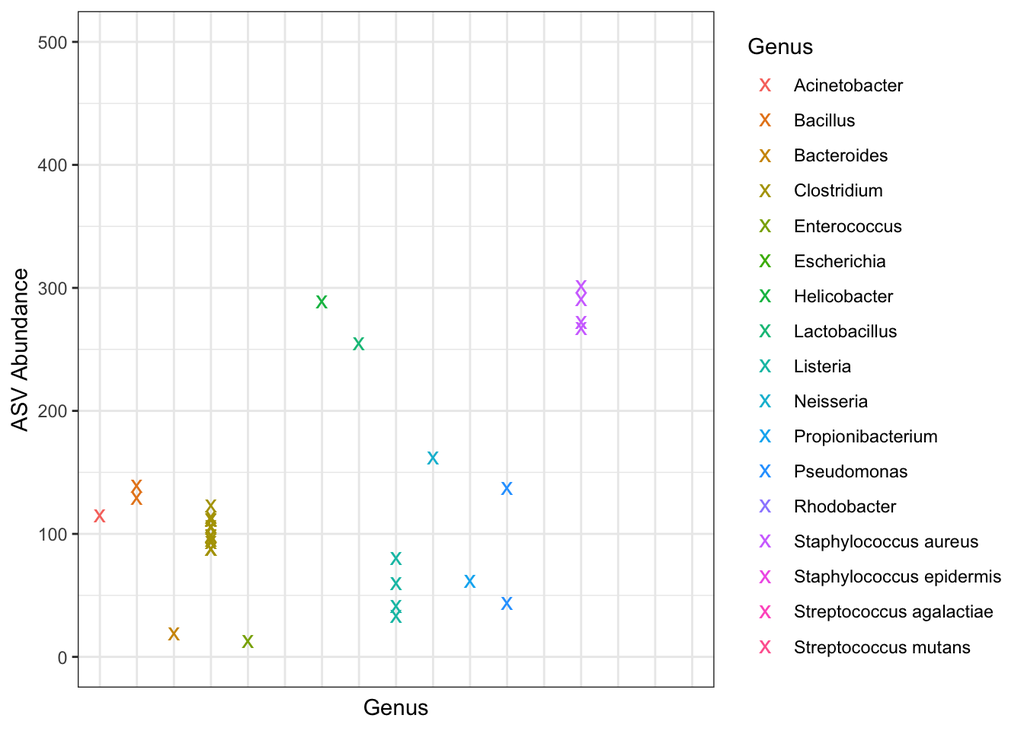

```r
p.abundasv + ylim(0, 500)
```

```r
summary(dfasv$Abundance)
```

```
##    Min. 1st Qu.  Median    Mean 3rd Qu.    Max.
##    13.0    96.5   137.0  1370.8  1785.5 14640.0
```

```r
summary(dfasv$Abundance)/sum(dfasv$Abundance)
```

```
##      Min.   1st Qu.    Median      Mean   3rd Qu.      Max.
## 0.0001859 0.0013803 0.0019596 0.0196078 0.0255396 0.2094091
```

Yep, broad range of abundances over 3 orders of magnitude at the genome and sequence-variant level. Concentrations of DNA from each strain, as assyaed by Qubit, are in the BEI Certificat of Analysis doc:

```r
qubit <- c("Acinetobacter" = 0.010,
           "Actinomyces"=0.001,
           "Bacillus" = 0.045,
           "Bacteroides" = 0.001,
           "Clostridium" = 0.044,
           "Deinococcus" = 0.001,
           "Enterococcus" = 0.001,
           "Escherichia" = 0.680,
           "Helicobacter" = 0.009,
           "Lactobacillus" = 0.003,
           "Listeria" = 0.005,
           "Neisseria" = 0.006,
           "Propionibacterium" = 0.009,
           "Pseudomonas" = 0.161,
           "Rhodobacter" = 1.413,
           "Staphylococcus aureus" = 0.059,
           "Staphylococcus epidermis" = 0.513,
           "Streptococcus agalactiae" = 0.032,
           "Streptococcus mutans" = 0.417,
           "Streptococcus pneumoniae" = 0.001)
```

Note that the dropouts (*S. pneumoniae*, *Deinococcus* and *Actinomyces*) all had the lowest Qubit measurements (0.001), which may be a minimum assigned value rather than a true value anyway (e.g. ND). These were too rare to detect.

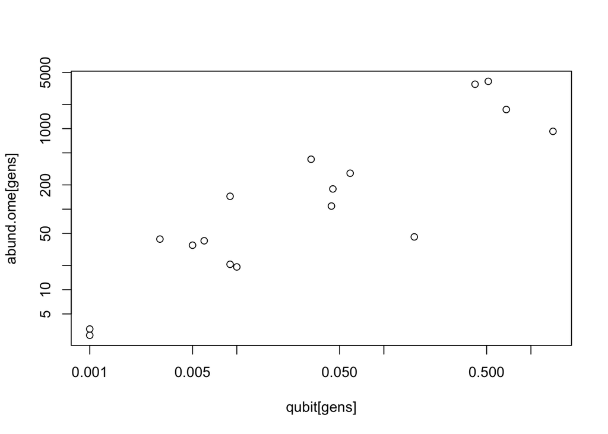

```r
plot(qubit[gens], abund.ome[gens], log="xy")
```

Decent correspondence.

And now we make the “stoichiometry” figure, i.e the abundance of each ASV scaled to the genomic abundance:

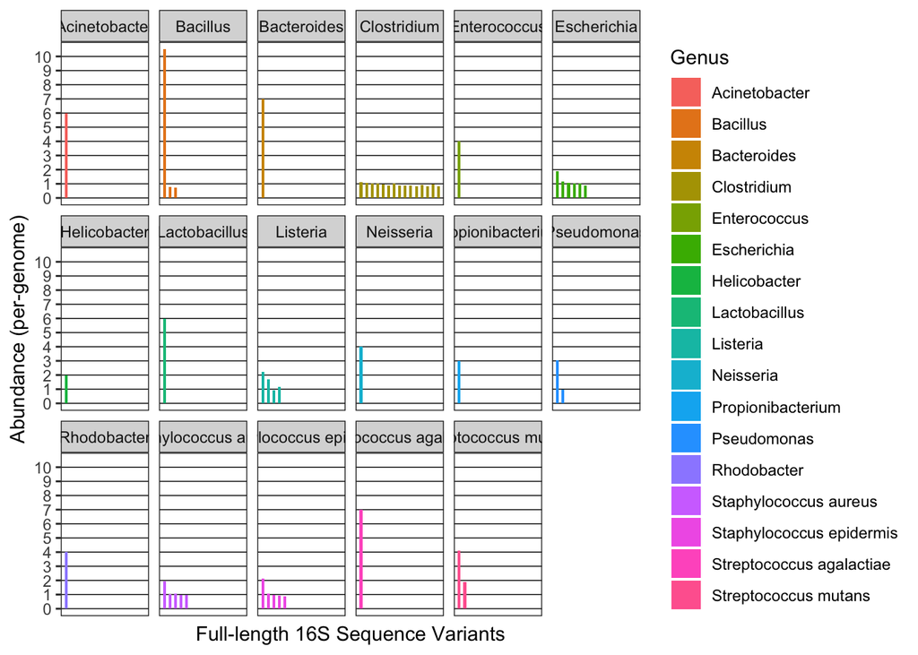

```r
dfasv$ScaledAbundance <- dfasv$Abundance/abund.ome[dfasv$Genus]
# Number the ASVs in each strain/genus
dfasv$Variant <- sapply(seq(nrow(dfasv)), function(i) sum(dfasv$Genus[1:i] == dfasv$Genus[[i]], na.rm=TRUE))

p.stoich <- ggplot(data=dfasv, aes(x=Variant, y=ScaledAbundance, fill=Genus, width=0.5)) + geom_col() +
  facet_wrap(~Genus, nrow=3) +
  scale_y_continuous(breaks=seq(0, round(max(dfasv$ScaledAbundance))), minor_breaks=NULL) +
  theme(panel.grid.major.y=element_line(color="black", size=0.25)) +
  theme(panel.grid.major.x=element_blank(), panel.grid.minor.x=element_blank()) +
  theme(axis.text.x=element_blank(), axis.ticks.x=element_blank()) +
  xlab("Full-length 16S Sequence Variants") +
  ylab("Abundance (per-genome)")
p.stoich
```

```r
ggsave(file.path(path.out, "HMP_Stoich.pdf"), width=12, height=7, units="in")
```

Now let’s put the genome abundances together with the integers in a simpler plot:

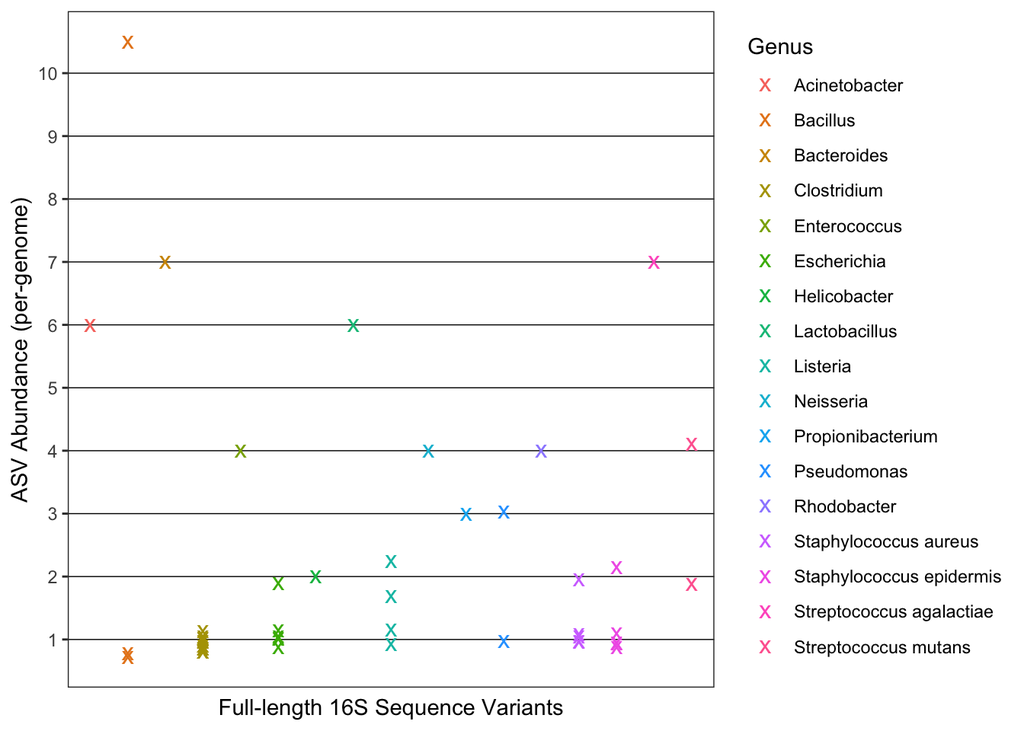

```r
p.stoich.nice <- ggplot(data=dfasv, aes(x=Genus, y=ScaledAbundance, color=Genus, width=0.5)) +
  geom_point(shape="x", size=4) +
  scale_y_continuous(breaks=seq(0, round(max(dfasv$ScaledAbundance))), minor_breaks=NULL) +
  theme(panel.grid.major.y=element_line(color="black", size=0.25)) +
  theme(panel.grid.major.x=element_blank(), panel.grid.minor.x=element_blank()) +
  theme(axis.text.x=element_blank(), axis.ticks.x=element_blank()) +
  xlab("Full-length 16S Sequence Variants") +
  ylab("ASV Abundance (per-genome)")
p.stoich.nice
```

```r
library(gridExtra)
```

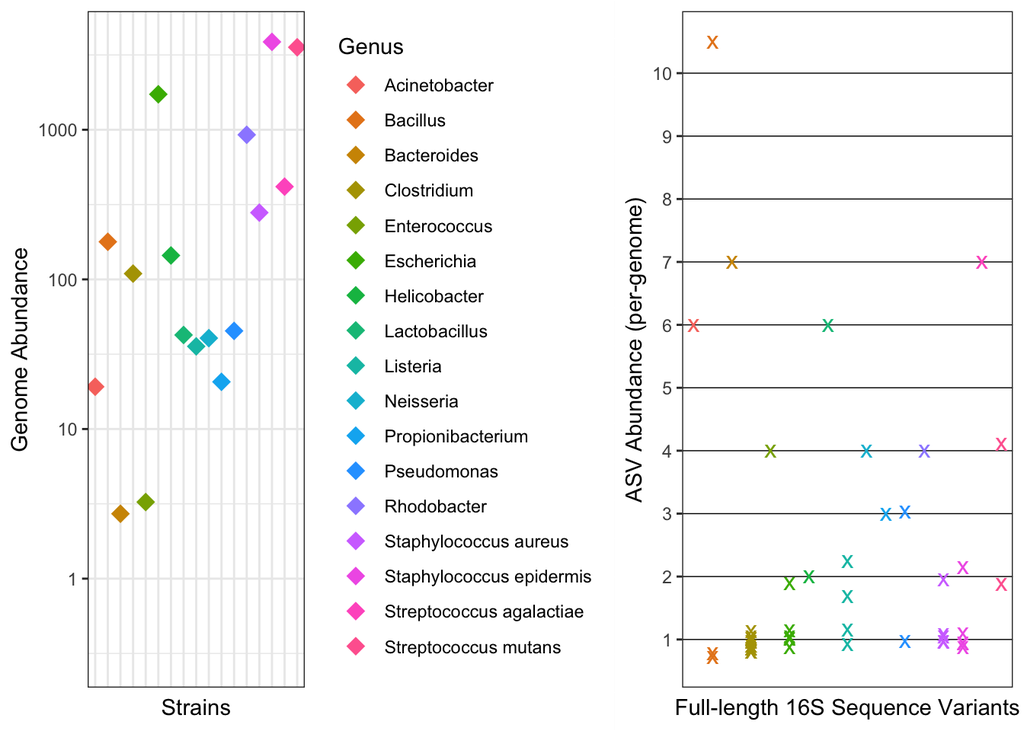

```r
p.nice <- arrangeGrob(p.abundome.nice, p.stoich.nice + guides(color=FALSE), nrow=1, widths=c(0.6, 0.4))
plot(p.nice)
```

```r
ggsave(file.path(path.out, "HMP_AbundanceAndStoich.pdf"), p.nice,
                 width=10, height=4, units="in", useDingbats=FALSE)
```

*B. cereus* a little off, and *Listeria* a little off. Others all look very good (although many are just one variant, so trivial integral-ness).

Some is due to low numbers as well, e.g *Listeria* seems largely down to counting noise:

```r
is.gen <- tax[,"Genus"] == "Listeria"
foo <- data.frame(denoised=dd$denoised[is.gen], n0=dd$clustering$n0[is.gen], exact=drp$uniques[dd$sequence[is.gen]])
rownames(foo) <- NULL
foo
```

```
##   denoised n0 exact
## 1       80 65    40
## 2       60 50    37
## 3       33 28    19
## 4       41 35    27
```

Diff between 1/2 increases a lot as reads are corrected. Might just be noise though, not huge numbers here.

However *Bacillus* is difficult to explain by counting noise. Could the rrn copy number be wrong? All three variants exactly match previously observed sequences so these ASVs being uncorrected sequencing errors seems unlikely.

For completeness, let’s calculate the residual error rate if those low-frequency *B. cereus* ASVs are errors:

```r
is.bc <- tax[,"Genus"] %in% "Bacillus"
sq.bc <- dd$sequence[is.bc]
# Candidate errors are the 2nd and 3rd B cereus ASVs
tot.err <- sum(nwhamming(sq.bc[[1]], sq.bc[2:3])*dd$denoised[sq.bc[2:3]])
tot.nt <- sum(dd$denoised * nchar(dd$sequence))
tot.err/tot.nt
```

```
## [1] 2.611897e-06
```